# Governance - Exploratory Factor Analysis

### Groupings From Factor Analysis

#### 6 Factors:

Variables( good meaning)

Group Names

- P12_Line_1: Accounting method is accural (bad is anything else)
- P4_Line_12: The organization obtains separate, independent audited financial statements
- P6_Line_12_13_14: The organization has a written conflict of interest policy, a written whistleblower policy, and a written retention and destruction policy
- Have good accounting practices and documented policies
- P6_LINE_8A: The meetings by the governing body are documented
  - Correlated with 8b. meetings by each committee are documented
- Open documenting of organizational business
- P6_LINE_15A: The org has a process for determining compensation of the CEO, executive director, or top management officials including a review and approval by independent persons, comparability data, and deliberation decision
  - Correlated with Line 15b. The org has a process for determining compensation of other officers or key employees includin a review and approval by independent persons, comparability data, and deliberation decision
- P6_Line_1: The percent of independent members on the voting board is >50%
- Good policies for making the board and for paying them
- (Negative) P6_LINE_3: The org did not use a management company or other person to perform any management duties
- The or ?did? using a management company
- P6_Line_11A: A copy of Form 990 is provided to all members before filing the form
- P6_Line_18: Forms 1023 (or 1024), 990, 990-T available for public inspection on own website
- IRS forms are available for public inspection
- (Negative) P4_Line_28: The org was **not** a party to a business transaction to with an entity of which a current or former officer, director, trustee, or key employee was an officer, director, trustee, or direct or indirect owner
- (Negative) P6_Line_2: **No** officer, director, trustee, or key employee had a family relationship or a business relationship with any other officer, director, trustee, or key employee?
- (Negative) P4_Line_29: Either (the org did not have more than $25K in cash contribution AND did not have receive any art/historical treasures/etc.) OR (they do have those things AND they do have a written policy about how to handle them)
- These are all about doing business with family or having large/expensive assests

#### 5 Factors:

Variables( good meaning)

Group Names

- P12_Line_1: Accounting method is accural (bad is anything else)
- P4_Line_12: The organization obtains separate, independent audited financial statements
- Have good accounting practices
- P6_LINE_8A: The meetings by the governing body are documented
  - Correlated with 8b. meetings by each committee are documented
- P6_Line_11A: A copy of Form 990 is provided to all members before filing the form
- Open documenting of organizational business
- P6_LINE_15A: The org has a process for determining compensation of the CEO, executive director, or top management officials including a review and approval by independent persons, comparability data, and deliberation decision
  - Correlated with Line 15b. The org has a process for determining compensation of other officers or key employees includin a review and approval by independent persons, comparability data, and deliberation decision
- P6_Line_12_13_14: The organization has a written conflict of interest policy, a written whistleblower policy, and a written retention and destruction policy
- P6_Line_18: Forms 1023 (or 1024), 990, 990-T available for public inspection on own website
- Having written policies available for inspection
- P6_LINE_3: The org did not use a management company or other person to perform any management duties
- no “subcontracting” management duties
- P6_Line_1: The percent of independent members on the voting board is >50%
- (Negative) P4_Line_28: The org was **not** a party to a business transaction to with an entity of which a current or former officer, director, trustee, or key employee was an officer, director, trustee, or direct or indirect owner
- (Negative) P6_Line_2: **No** officer, director, trustee, or key employee had a family relationship or a business relationship with any other officer, director, trustee, or key employee?
- (Negative) P4_Line_29: Either (the org did not have more than $25K in cash contribution AND did not have receive any art/historical treasures/etc.) OR (they do have those things AND they do have a written policy about how to handle them)
- This is something about having independent voting members.

#### 4 Factors:

Variable Names

Potential Group

- P12_Line_1: Accounting method is accural (bad is anything else)
- P4_Line_12: The organization obtains separate, independent audited financial statements
- P6_Line_12_13_14: The organization has a written conflict of interest policy, a written whistleblower policy, and a written retention and destruction policy
- Have good accounting practices and documented policies
- P6_LINE_8A: The meetings by the governing body are documented
  - Correlated with 8b. meetings by each committee are documented
- P6_Line_11A: A copy of Form 990 is provided to all members before filing the form
- P6_LINE_15A: The org has a process for determining compensation of the CEO, executive director, or top management officials including a review and approval by independent persons, comparability data, and deliberation decision
  - Correlated with Line 15b. The org has a process for determining compensation of other officers or key employees including a review and approval by independent persons, comparability data, and deliberation decision
- P6_Line_1: The percent of independent members on the voting board is >50%
- These are all about the governing body, the hiring process, the documentation, and the tax documents
- (Negative) P4_Line_28: The org was **not** a party to a business transaction to with an entity of which a current or former officer, director, trustee, or key employee was an officer, director, trustee, or direct or indirect owner
- (Negative) P6_Line_2: **No** officer, director, trustee, or key employee had a family relationship or a business relationship with any other officer, director, trustee, or key employee?
- About family relationships
- P6_LINE_3: The org did not use a management company or other person to perform any management duties
- P6_Line_18: Forms 1023 (or 1024), 990, 990-T available for public inspection on own website
- (Negative) P4_Line_29: Either (the org did not have more than $25K in cash contribution AND did not have receive any art/historical treasures/etc.) OR (they do have those things AND they do have a written policy about how to handle them)
- IDK about this one

## PCA

### 4 Factors

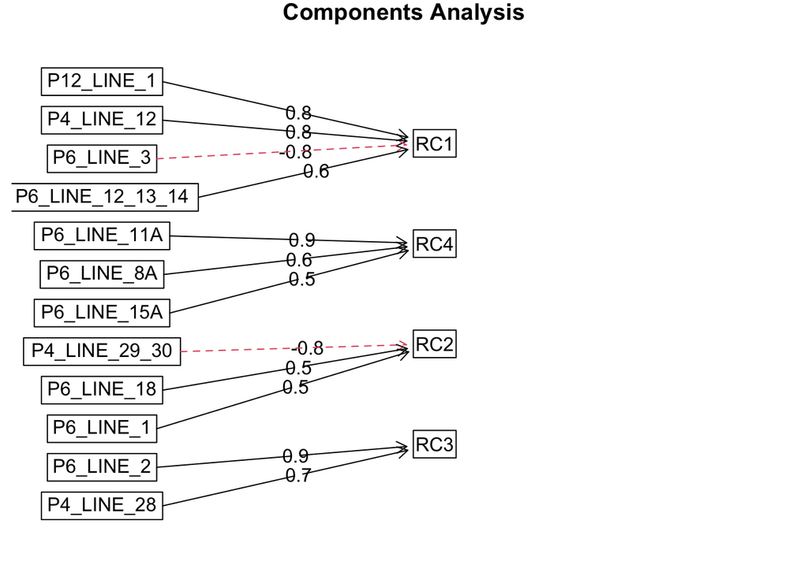

```r
pca.out <- principal(rho2, nfactors = 4, rotate = "equamax")

fa.diagram(pca.out)
```

## Save design matrix

```r
## Save design matrix
save(features2, file = "governance/governance-design-matrix.Rdata")
```

## Results

We are choosing to use the 6 factor model for assigning factor scores.